# SVM Practical

## Blood Brain Barrier (Regression)

On the BBB dataset, we would like to compare all 4 types of model and how they perform on the test dataset. Firstly, we will prepare the dataset as usual:

```r
library(caret)
# Load BBB data
data(BloodBrain)

# Split into training and test
set.seed(42)
trainIndex <- createDataPartition(y=logBBB, times=1, p=0.8, list=F)
descrTrain <- bbbDescr[trainIndex,]
concRatioTrain <- logBBB[trainIndex]
descrTest <- bbbDescr[-trainIndex,]
concRatioTest <- logBBB[-trainIndex]

# Preprocess training data
transformations <- preProcess(descrTrain,
                              method=c("corr", "nzv", "scale", "center"),
                              cutoff=0.75)
descrTrain <- predict(transformations, descrTrain)
```

We then set up our 5-fold cross validation as usual:

```r
# Set up seeds
set.seed(42)
seeds <- vector(mode = "list", length = 6)
for(i in 1:5) seeds[[i]] <- sample.int(1000, 9)
seeds[[6]] <- sample.int(1000,1)
trainctrl = trainControl(method="cv",
                        number = 5,
                        seeds=seeds)
```

For consistency with the lecture on Monday, we are going to use the E1071 implementation of a radial SVM, defined below.

```r
svmRadialE1071 <- list(
  label = "Support Vector Machines with Radial Kernel - e1071",
  library = "e1071",
  type = c("Regression", "Classification"),
  parameters = data.frame(parameter="cost",
                          class="numeric",
                          label="Cost"),
  grid = function (x, y, len = NULL, search = "grid")
    {
      if (search == "grid") {
        out <- expand.grid(cost = 2^((1:len) - 3))
      }
      else {
        out <- data.frame(cost = 2^runif(len, min = -5, max = 10))
      }
      out
    },
  loop=NULL,
  fit=function (x, y, wts, param, lev, last, classProbs, ...)
    {
      if (any(names(list(...)) == "probability") | is.numeric(y)) {
        out <- e1071::svm(x = as.matrix(x), y = y, kernel = "radial",
                          cost = param$cost, ...)
      }
      else {
        out <- e1071::svm(x = as.matrix(x), y = y, kernel = "radial",
                          cost = param$cost, probability = classProbs, ...)
      }
      out
    },
  predict = function (modelFit, newdata, submodels = NULL)
    {
      predict(modelFit, newdata)
    },
  prob = function (modelFit, newdata, submodels = NULL)
    {
      out <- predict(modelFit, newdata, probability = TRUE)
      attr(out, "probabilities")
    },
  predictors = function (x, ...)
    {
      out <- if (!is.null(x$terms))
        predictors.terms(x$terms)
      else x$xNames
      if (is.null(out))
        out <- names(attr(x, "scaling")$x.scale$`scaled:center`)
      if (is.null(out))
        out <- NA
      out
    },
  tags = c("Kernel Methods", "Support Vector Machines", "Regression", "Classifier", "Robust Methods"),
  levels = function(x) x$levels,
  sort = function(x)
  {
    x[order(x$cost), ]
  }
)
```

We now train a kNN, decision tree, random forest and radial SVM, each with 9 hyperparameter values.

```r
knnTune <- train(descrTrain,
                 concRatioTrain,
                 method='knn',
                 tuneLength = 9,
                 trControl = trainctrl)
knnTune
```

```
## k-Nearest Neighbors
##
## 168 samples
##  63 predictor
##
## No pre-processing
## Resampling: Cross-Validated (5 fold)
## Summary of sample sizes: 135, 134, 135, 135, 133
## Resampling results across tuning parameters:
##
##   k   RMSE       Rsquared   MAE
##    5  0.6181827  0.3982391  0.4592714
##    7  0.6311584  0.3834876  0.4776704
##    9  0.6432032  0.3607684  0.4889551
##   11  0.6348904  0.3908828  0.4784986
##   13  0.6373026  0.3872824  0.4778049
##   15  0.6346500  0.4055803  0.4720703
##   17  0.6358174  0.4112192  0.4764774
##   19  0.6473553  0.3924592  0.4830334
##   21  0.6517247  0.3976232  0.4869952
##
## RMSE was used to select the optimal model using the smallest value.
## The final value used for the model was k = 5.
```

```r
dtTune <- train(descrTrain,
                 concRatioTrain,
                 method='rpart',
                 tuneLength = 9,
                 trControl = trainctrl)
dtTune
```

```
## CART
##
## 168 samples
##  63 predictor
##
## No pre-processing
## Resampling: Cross-Validated (5 fold)
## Summary of sample sizes: 135, 135, 133, 135, 134
## Resampling results across tuning parameters:
##
##   cp          RMSE       Rsquared    MAE
##   0.01806336  0.7137291  0.29818115  0.5541661
##   0.02477565  0.7154837  0.29600518  0.5496488
##   0.03155690  0.7262224  0.28033324  0.5600798
##   0.05241187  0.7088529  0.26804246  0.5448448
##   0.05465950  0.7088529  0.26804246  0.5448448
##   0.06435226  0.7088529  0.26804246  0.5448448
##   0.09019924  0.7214021  0.23432669  0.5434535
##   0.13642255  0.7351341  0.18791115  0.5766127
##   0.27502543  0.7896188  0.07458217  0.6289191
##
## RMSE was used to select the optimal model using the smallest value.
## The final value used for the model was cp = 0.06435226.
```

```r
rfTune <- train(descrTrain,
                 concRatioTrain,
                 method='rf',
                 tuneLength = 9,
                 trControl = trainctrl)
rfTune
```

```
## Random Forest
##
## 168 samples
##  63 predictor
##
## No pre-processing
## Resampling: Cross-Validated (5 fold)
## Summary of sample sizes: 135, 135, 133, 135, 134
## Resampling results across tuning parameters:
##
##   mtry  RMSE       Rsquared   MAE
##    2    0.5546652  0.5613877  0.4207149
##    9    0.5313394  0.5713170  0.4007412
##   17    0.5236485  0.5783092  0.3963332
##   24    0.5221394  0.5778983  0.3949499
##   32    0.5289290  0.5646158  0.4013016
##   40    0.5274985  0.5620133  0.3994993
##   47    0.5265310  0.5653075  0.4014358
##   55    0.5376913  0.5405153  0.4074395
##   63    0.5355160  0.5451226  0.4028083
##
## RMSE was used to select the optimal model using the smallest value.
## The final value used for the model was mtry = 24.
```

```r
svmTune <- train(descrTrain,
                 concRatioTrain,
                 method=svmRadialE1071,
                 tuneLength = 9,
                 trControl = trainctrl)
svmTune
```

```
## Support Vector Machines with Radial Kernel - e1071
##
## 168 samples
##  63 predictor
##
## No pre-processing
## Resampling: Cross-Validated (5 fold)
## Summary of sample sizes: 134, 133, 136, 134, 135
## Resampling results across tuning parameters:
##
##   cost   RMSE       Rsquared   MAE
##    0.25  0.6259498  0.4725057  0.4621817
##    0.50  0.5827760  0.5123595  0.4340310
##    1.00  0.5583455  0.5218735  0.4210038
##    2.00  0.5341795  0.5491784  0.4014789
##    4.00  0.5328158  0.5521030  0.3971636
##    8.00  0.5338141  0.5510011  0.3979414
##   16.00  0.5338141  0.5510011  0.3979414
##   32.00  0.5338141  0.5510011  0.3979414
##   64.00  0.5338141  0.5510011  0.3979414
##
## RMSE was used to select the optimal model using the smallest value.
## The final value used for the model was cost = 4.
```

Next, we test each model on the test dataset

```r
descrTest <- predict(transformations, descrTest)
test_pred_knn <- predict(knnTune, descrTest)
test_pred_dtree <- predict(dtTune, descrTest)
test_pred_rf <- predict(rfTune, descrTest)
test_pred_svm <- predict(svmTune, descrTest)
```

To compare the models against each other, we plot the predicted values against each other in a scatter plot and calculate the correlation between each set of predictions:

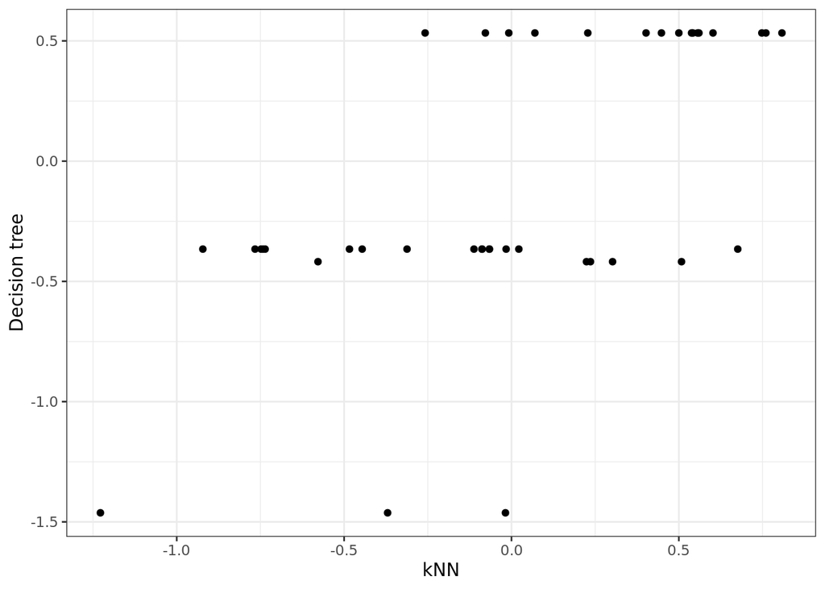

```r
qplot(test_pred_knn, test_pred_dtree) + xlab("kNN") + ylab("Decision tree") + theme_bw()
```

```r
cor(test_pred_knn, test_pred_dtree)
```

```
## [1] 0.6100335
```

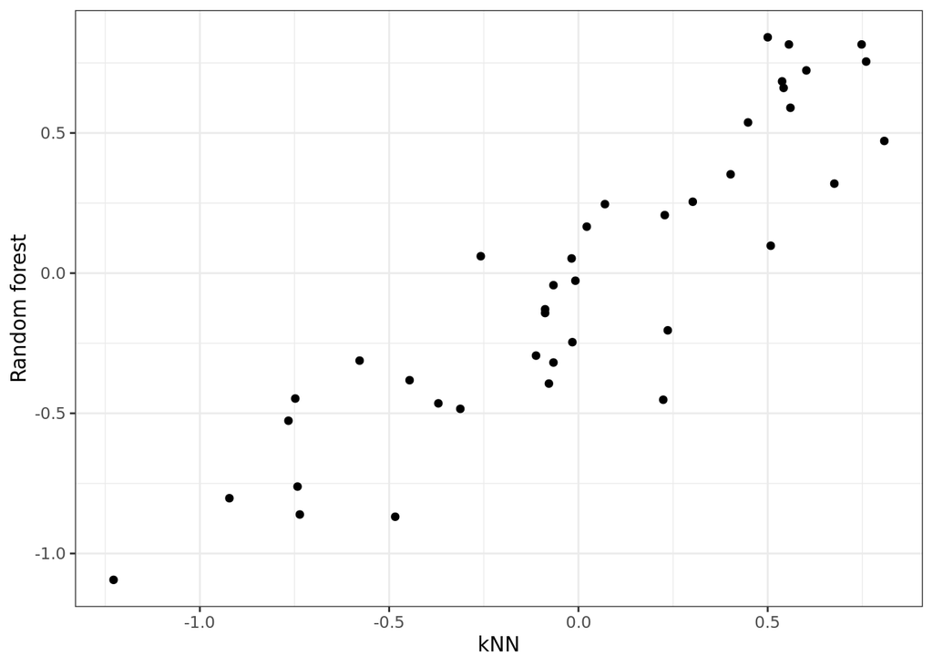

```r
qplot(test_pred_knn, test_pred_rf) + xlab("kNN") + ylab("Random forest") + theme_bw()
```

```r
cor(test_pred_knn, test_pred_rf)
```

```
## [1] 0.9014785
```

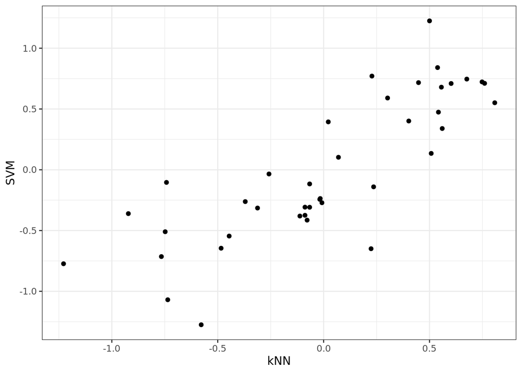

```r
qplot(test_pred_knn, test_pred_svm) + xlab("kNN") + ylab("SVM") + theme_bw()
```

```r
cor(test_pred_knn, test_pred_svm)
```

```
## [1] 0.8158671
```

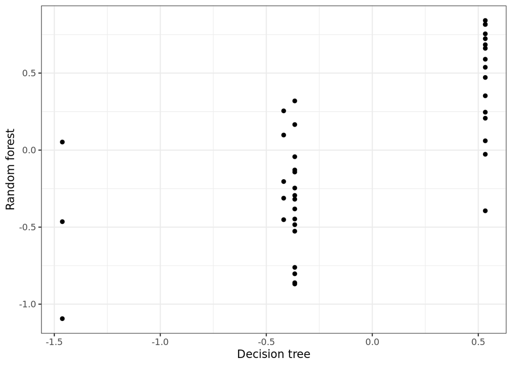

```r
qplot(test_pred_dtree, test_pred_rf) + xlab("Decision tree") + ylab("Random forest") + theme_bw()
```

```r
cor(test_pred_dtree, test_pred_rf)
```

```
## [1] 0.6868559
```

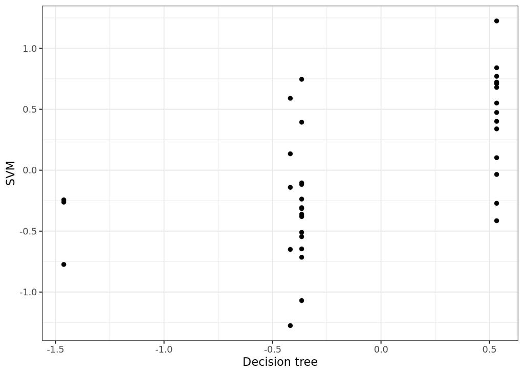

```r
qplot(test_pred_dtree, test_pred_svm) + xlab("Decision tree") + ylab("SVM") + theme_bw()
```

```r
cor(test_pred_dtree, test_pred_svm)
```

```
## [1] 0.6028287
```

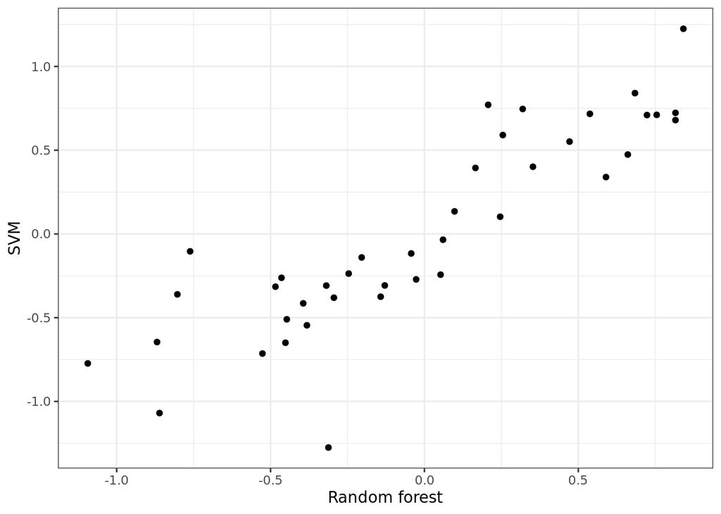

```r
qplot(test_pred_rf, test_pred_svm) + xlab("Random forest") + ylab("SVM") + theme_bw()
```

```r
cor(test_pred_rf, test_pred_svm)
```

```
## [1] 0.875369
```

## Cell segmentation

Now, we focus on the cell segmentation data. In the lecture on Monday, we only tried a radial kernel SVM so now we will try out some other kernel options, namely linear and polynomial. First of all, we prepare the dataset and the cross-validation as usual:

```r
# Load data
data(segmentationData)
segClass <- segmentationData$Class
segData <- segmentationData[,4:59]

# Split into training and test
set.seed(42)
trainIndex <- createDataPartition(y=segClass, times=1, p=0.5, list=F)
segDataTrain <- segData[trainIndex,]
segDataTest <- segData[-trainIndex,]
segClassTrain <- segClass[trainIndex]
segClassTest <- segClass[-trainIndex]

# Set up cross-validation
set.seed(42)
seeds <- vector(mode = "list", length = 6)
for(i in 1:5) seeds[[i]] <- sample.int(1000, 243)
seeds[[6]] <- sample.int(1000,1)
cvCtrl <- trainControl(method = "cv",
#                       repeats = 5,
                       number = 5,
                       summaryFunction = twoClassSummary,
                       classProbs = TRUE,
                       seeds=seeds)
```

Now we train a linear, polynomial and radial SVM and plot their performance on each fold of the training data together.

```r
library(doParallel)
cl <- makePSOCKcluster(5)
registerDoParallel(cl)

svmLinearTune <- train(x = segDataTrain,
                   y = segClassTrain,
                   method = 'svmLinear',
                   tuneLength = 3,
                   preProc = c("nzv", "corr", "scale", "center"),
                   metric = "ROC",
                   trControl = cvCtrl)

svmPolyTune <- train(x = segDataTrain,
                   y = segClassTrain,
                   method = 'svmPoly',
                   tuneLength = 3,
                   preProc = c("nzv", "corr", "scale", "center"),
                   metric = "ROC",
                   trControl = cvCtrl)

svmRadialTune <- train(x = segDataTrain,
                   y = segClassTrain,
                   method = 'svmRadial',
                   tuneLength = 3,
                   preProc = c("nzv", "corr", "scale", "center"),
                   metric = "ROC",
                   trControl = cvCtrl)

## When you are done:
stopCluster(cl)

resamps <- resamples(list(svmLinear = svmLinearTune, svmPoly = svmPolyTune, svmRadial = svmRadialTune))
summary(resamps)
```

```
##
## Call:
## summary.resamples(object = resamps)
##
## Models: svmLinear, svmPoly, svmRadial
## Number of resamples: 5
##
## ROC
##                Min.   1st Qu.    Median      Mean   3rd Qu.      Max. NA's
## svmLinear 0.7929487 0.8535256 0.8706197 0.8674145 0.9057692 0.9142094    0
## svmPoly   0.8548077 0.8631410 0.8803419 0.8739744 0.8806624 0.8909188    0
## svmRadial 0.8619658 0.8642094 0.8861111 0.8801068 0.8941239 0.8941239    0
##
## Sens
##                Min.   1st Qu.    Median      Mean   3rd Qu.      Max. NA's
## svmLinear 0.8076923 0.8538462 0.8692308 0.8661538 0.8692308 0.9307692    0
## svmPoly   0.8538462 0.8692308 0.8692308 0.8692308 0.8769231 0.8769231    0
## svmRadial 0.8538462 0.8692308 0.8692308 0.8707692 0.8692308 0.8923077    0
##
## Spec
##                Min.   1st Qu.    Median      Mean   3rd Qu.      Max. NA's
## svmLinear 0.5555556 0.5694444 0.6666667 0.6361111 0.6944444 0.6944444    0
## svmPoly   0.6388889 0.6527778 0.6666667 0.6694444 0.6944444 0.6944444    0
## svmRadial 0.6250000 0.6666667 0.6805556 0.6777778 0.7083333 0.7083333    0
```

```r
resamps.df = as.data.frame(resamps)
resamps.df.melt = reshape2::melt(resamps.df,id_vars=c('Resample'))
```

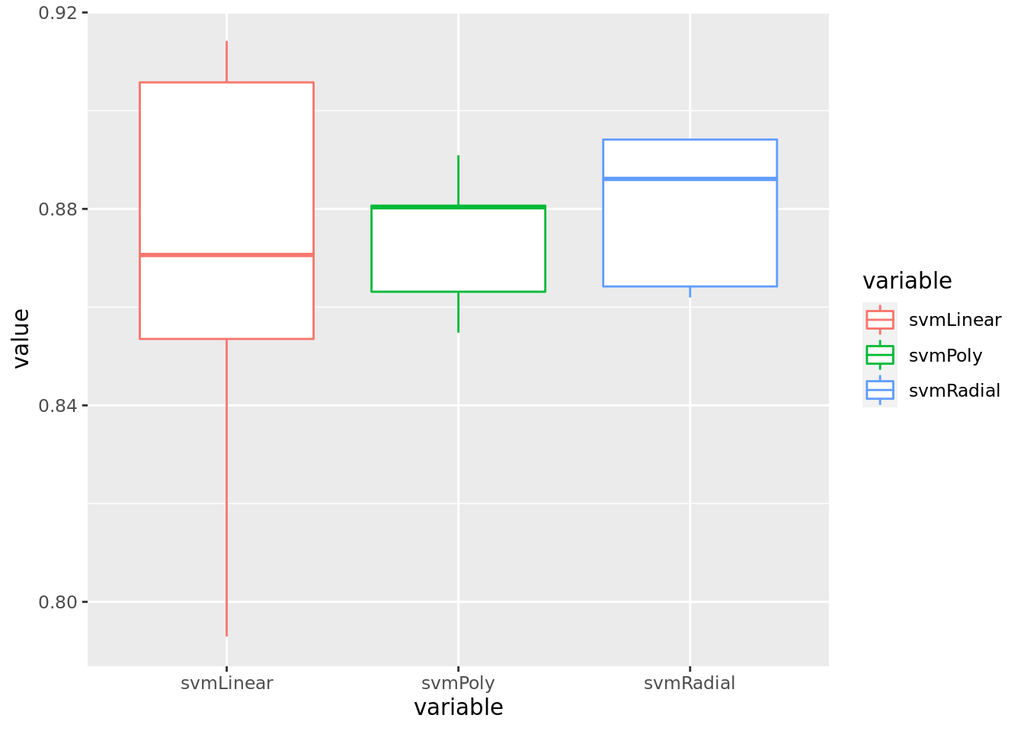

```r
ggplot(resamps.df.melt,aes(x=variable,y=value,color=variable))+geom_boxplot()
```

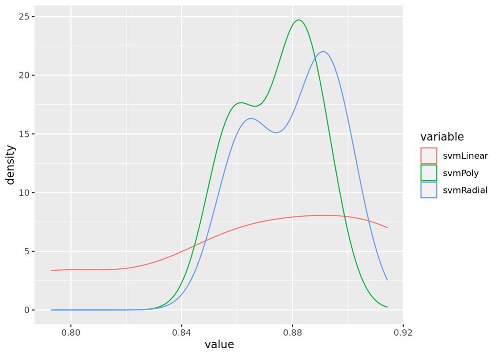

```r
ggplot(resamps.df.melt,aes(x=value,y=..density..,color=variable))+geom_density()
```

Next, we want to compare the performance of SVMs and the other types of models, namely kNN, decision tree, random forest and SVM. We train each type of model and test them on our unseen test data.

```r
cl <- makePSOCKcluster(5)
registerDoParallel(cl)

knnTune <- train(x = segDataTrain,
                   y = segClassTrain,
                   method = 'knn',
                   tuneLength = 9,
                   preProc = c("nzv", "corr", "scale", "center"),
                   metric = "ROC",
                   trControl = cvCtrl)

dtTune <- train(x = segDataTrain,
                   y = segClassTrain,
                   method = 'rpart',
                   tuneLength = 9,
                   preProc = c("nzv", "corr", "scale", "center"),
                   metric = "ROC",
                   trControl = cvCtrl)

rfTune <- train(x = segDataTrain,
                   y = segClassTrain,
                   method = 'rf',
                   tuneLength = 9,
                   preProc = c("nzv", "corr", "scale", "center"),
                   metric = "ROC",
                   trControl = cvCtrl)

test_pred_knn <- predict(knnTune, segDataTest)
confusionMatrix(test_pred_knn, segClassTest)
```

```
## Confusion Matrix and Statistics
##
##           Reference
## Prediction  PS  WS
##         PS 562 112
##         WS  88 247
##
##                Accuracy : 0.8018
##                  95% CI : (0.7758, 0.826)
##     No Information Rate : 0.6442
##     P-Value [Acc > NIR] : <2e-16
##
##                   Kappa : 0.561
##
##  Mcnemar's Test P-Value : 0.1039
##
##             Sensitivity : 0.8646
##             Specificity : 0.6880
##          Pos Pred Value : 0.8338
##          Neg Pred Value : 0.7373
##              Prevalence : 0.6442
##          Detection Rate : 0.5570
##    Detection Prevalence : 0.6680
##       Balanced Accuracy : 0.7763
##
##        'Positive' Class : PS
##
```

```r
test_pred_dtree <- predict(dtTune, segDataTest)
confusionMatrix(test_pred_dtree, segClassTest)
```

```
## Confusion Matrix and Statistics
##
##           Reference
## Prediction  PS  WS
##         PS 548 107
##         WS 102 252
##
##                Accuracy : 0.7929
##                  95% CI : (0.7665, 0.8175)
##     No Information Rate : 0.6442
##     P-Value [Acc > NIR] : <2e-16
##
##                   Kappa : 0.5467
##
##  Mcnemar's Test P-Value : 0.782
##
##             Sensitivity : 0.8431
##             Specificity : 0.7019
##          Pos Pred Value : 0.8366
##          Neg Pred Value : 0.7119
##              Prevalence : 0.6442
##          Detection Rate : 0.5431
##    Detection Prevalence : 0.6492
##       Balanced Accuracy : 0.7725
##
##        'Positive' Class : PS
##
```

```r
test_pred_rf <- predict(rfTune, segDataTest)
confusionMatrix(test_pred_rf, segClassTest)
```

```
## Confusion Matrix and Statistics
##
##           Reference
## Prediction  PS  WS
##         PS 574 108
##         WS  76 251
##
##                Accuracy : 0.8176
##                  95% CI : (0.7924, 0.841)
##     No Information Rate : 0.6442
##     P-Value [Acc > NIR] : < 2e-16
##
##                   Kappa : 0.5941
##
##  Mcnemar's Test P-Value : 0.02229
##
##             Sensitivity : 0.8831
##             Specificity : 0.6992
##          Pos Pred Value : 0.8416
##          Neg Pred Value : 0.7676
##              Prevalence : 0.6442
##          Detection Rate : 0.5689
##    Detection Prevalence : 0.6759
##       Balanced Accuracy : 0.7911
##
##        'Positive' Class : PS
##
```

```r
test_pred_svm <- predict(svmRadialTune, segDataTest)
confusionMatrix(test_pred_svm, segClassTest)
```

```
## Confusion Matrix and Statistics
##
##           Reference
## Prediction  PS  WS
##         PS 574 114
##         WS  76 245
##
##                Accuracy : 0.8117
##                  95% CI : (0.7862, 0.8354)
##     No Information Rate : 0.6442
##     P-Value [Acc > NIR] : < 2.2e-16
##
##                   Kappa : 0.5793
##
##  Mcnemar's Test P-Value : 0.007269
##
##             Sensitivity : 0.8831
##             Specificity : 0.6825
##          Pos Pred Value : 0.8343
##          Neg Pred Value : 0.7632
##              Prevalence : 0.6442
##          Detection Rate : 0.5689
##    Detection Prevalence : 0.6819
##       Balanced Accuracy : 0.7828
##
##        'Positive' Class : PS
##
```

```r
confusionMatrix(test_pred_rf, test_pred_svm)
```

```
## Confusion Matrix and Statistics
##
##           Reference
## Prediction  PS  WS
##         PS 651  31
##         WS  37 290
##
##                Accuracy : 0.9326
##                  95% CI : (0.9153, 0.9473)
##     No Information Rate : 0.6819
##     P-Value [Acc > NIR] : <2e-16
##
##                   Kappa : 0.8454
##
##  Mcnemar's Test P-Value : 0.5443
##
##             Sensitivity : 0.9462
##             Specificity : 0.9034
##          Pos Pred Value : 0.9545
##          Neg Pred Value : 0.8869
##              Prevalence : 0.6819
##          Detection Rate : 0.6452
##    Detection Prevalence : 0.6759
##       Balanced Accuracy : 0.9248
##
##        'Positive' Class : PS
##
```

```r
stopCluster(cl)
```

To understand the differences between the predictions from each type of model, we find all the ‘PS’ and ‘WS’ predicted examples for each model and compare them in upset plots.

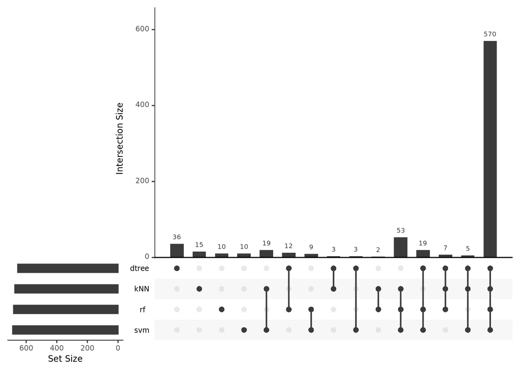

```r
ps_knn = which(test_pred_knn=='PS')
ps_dtree = which(test_pred_dtree=='PS')
ps_rf = which(test_pred_rf=='PS')
ps_svm = which(test_pred_svm=='PS')

ws_knn = which(test_pred_knn=='WS')
ws_dtree = which(test_pred_dtree=='WS')
ws_rf = which(test_pred_rf=='WS')
ws_svm = which(test_pred_svm=='WS')

library(UpSetR)
upset(fromList(list('kNN'=ps_knn,'dtree'=ps_dtree,'rf'=ps_rf,'svm'=ps_svm)))
```

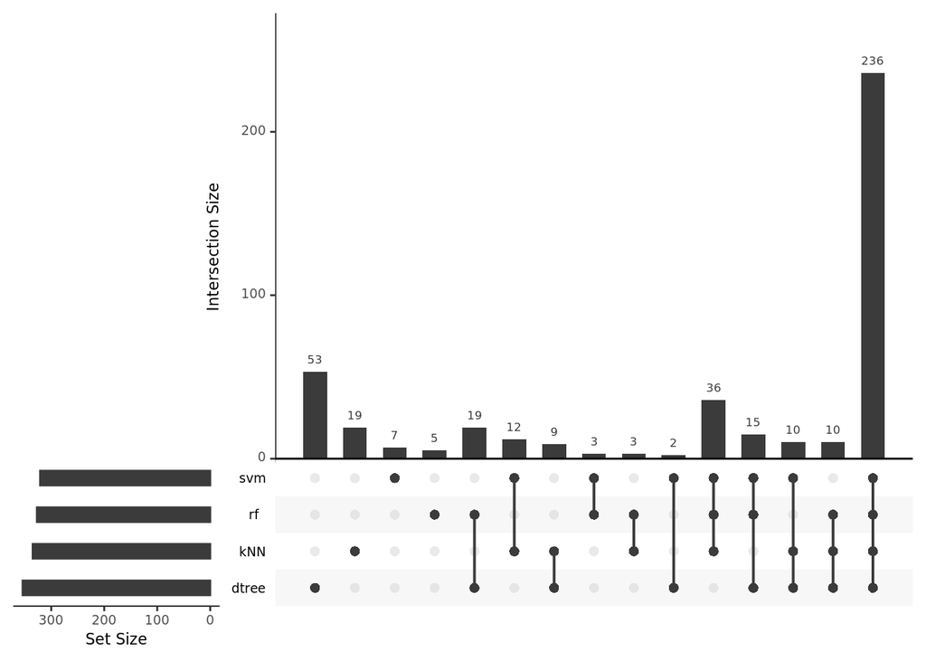

```r
upset(fromList(list('kNN'=ws_knn,'dtree'=ws_dtree,'rf'=ws_rf,'svm'=ws_svm)))
```